# Decision Trees Obesity

```python
!pip install pycountry_convert
# Load libraries and Functions
import pycountry_convert as pc
import numpy as np
import pandas as pd
import scipy
import matplotlib.pyplot as plt
import seaborn as sns
import os
from statsmodels.datasets import get_rdataset
from sklearn import metrics
from sklearn.preprocessing import StandardScaler
from numpy.linalg import svd
from scipy.stats import pearsonr
from sklearn.decomposition import PCA
from sklearn.metrics import mean_squared_error
from sklearn.cluster import KMeans
from sklearn.metrics import confusion_matrix
from sklearn.metrics import silhouette_score
from scipy.cluster.hierarchy import linkage, dendrogram
from matplotlib.colors import ListedColormap
from sklearn.decomposition import TruncatedSVD
from sklearn.cluster import AgglomerativeClustering
from scipy.cluster.hierarchy import cut_tree
from sklearn.preprocessing import StandardScaler, LabelEncoder
from scipy.cluster.hierarchy import cut_tree, dendrogram
from sklearn.preprocessing import LabelEncoder

from sklearn.tree import DecisionTreeClassifier, export_text, plot_tree, DecisionTreeRegressor
from sklearn.preprocessing import OneHotEncoder, LabelBinarizer
from sklearn.model_selection import train_test_split, GridSearchCV

from sklearn.ensemble import RandomForestRegressor, GradientBoostingRegressor
from sklearn.model_selection import train_test_split
from sklearn.inspection import PartialDependenceDisplay
from sklearn.ensemble import RandomForestClassifier
from sklearn.ensemble import GradientBoostingClassifier
```

# 1. Data preparation

## 1.1 Main Dataset: Prevalence of adult overweight obesity among adults in countries around the world

```python
# Prepare data
obesity_data = pd.read_csv('https://raw.githubusercontent.com/erdenetuya2080/DATA5322-Machine-Learning-II/main/Practical%20Homework%20IV_Unsupervised%20Learning/Datasets/adult_obesity.csv', encoding='latin1')

# Data clean
obesity_clean = obesity_data[[
    'Country',
    'Year',
    'Age',
    'Males Overweight (BMI 25-29.9kg/m²)',
    'Males Obesity (BMI ?30kg/m²)',
    'Females Overweight (BMI 25-29.9kg/m²)',
    'Females Obesity (BMI ?30kg/m²)',
    'Adults Overweight (BMI 25-29.9kg/m²)',
    'Adults Obesity (BMI ?30kg/m²)'
]].rename(columns={
    'Males Overweight (BMI 25-29.9kg/m²)': 'Males_Overweight',
    'Males Obesity (BMI ?30kg/m²)': 'Males_Obesity',
    'Females Overweight (BMI 25-29.9kg/m²)': 'Females_Overweight',
    'Females Obesity (BMI ?30kg/m²)': 'Females_Obesity',
    'Adults Overweight (BMI 25-29.9kg/m²)': 'Adults_Overweight',
    'Adults Obesity (BMI ?30kg/m²)': 'Adults_Obesity'
})
cols_to_fix = ['Males_Overweight', 'Males_Obesity', 'Females_Overweight', 'Females_Obesity', 'Adults_Overweight', 'Adults_Obesity']

for col in cols_to_fix:
    obesity_clean[col] = obesity_clean[col].str.replace(',', '.', regex=False)
    obesity_clean[col] = pd.to_numeric(obesity_clean[col], errors='coerce')

# Drop missing rows
obesity_clean = obesity_clean.dropna()
obesity_clean = obesity_clean.dropna(subset=cols_to_fix)

# Filter only adult groups starting with '18'
obesity_clean = obesity_clean[obesity_clean['Age'].str.contains(r'^18', na=False)]

# Drop the Age column since we only kept adult rows
obesity_clean = obesity_clean.drop(columns=['Age'])

# Extract only the starting ("2017-2018" → 2017)
obesity_clean['Year'] = obesity_clean['Year'].str.extract(r'(\d{4})').astype(int)
obesity_clean.info()
obesity_clean.head()
```

```
<class 'pandas.core.frame.DataFrame'>
Index: 80 entries, 0 to 247
Data columns (total 8 columns):
 #   Column              Non-Null Count  Dtype
---  ------              --------------  -----
 0   Country             80 non-null     object
 1   Year                80 non-null     int64
 2   Males_Overweight    80 non-null     float64
 3   Males_Obesity       80 non-null     float64
 4   Females_Overweight  80 non-null     float64
 5   Females_Obesity     80 non-null     float64
 6   Adults_Overweight   80 non-null     float64
 7   Adults_Obesity      80 non-null     float64
dtypes: float64(6), int64(1), object(1)
memory usage: 5.6+ KB
```

|  | Country | Year | Males_Overweight | Males_Obesity | Females_Overweight | Females_Obesity | Adults_Overweight | Adults_Obesity |
| --- | --- | --- | --- | --- | --- | --- | --- | --- |
| 0 | Afghanistan | 2018 | 25.9 | 11.9 | 25.6 | 23.5 | 25.8 | 17.0 |
| 2 | Algeria | 2016 | 34.2 | 14.1 | 33.2 | 30.1 | 33.8 | 21.8 |
| 4 | Andorra | 2017 | 42.5 | 13.0 | 27.0 | 14.4 | 35.2 | 13.6 |
| 6 | Anguilla | 2016 | 36.0 | 30.4 | 27.4 | 46.5 | 31.7 | 38.5 |
| 8 | Argentina | 2018 | 38.7 | 31.4 | 29.1 | 33.4 | 33.7 | 32.4 |

Result: The resulting dataset is a clean, numeric collection of adult only obesity indicators, including male, female, and overall overweight and obesity rates, organized by country and year.

## 1.2 Supporting Dataset: World Development Indicators

```python
# Prepare data


world_data = pd.read_csv('https://raw.githubusercontent.com/erdenetuya2080/DATA5322-Machine-Learning-II/main/Practical%20Homework%20IV_Unsupervised%20Learning/Datasets/world_data.csv')

# Drop unnecessary columns
world_data_cleaned = world_data.drop(columns=['Country Code', 'Series Code'])

world_long = pd.melt(
    world_data_cleaned,
    id_vars=['Country Name', 'Series Name'],
    var_name='Year',
    value_name='Value'
)

# Extract numeric year
world_long['Year'] = world_long['Year'].str.extract(r'(\d{4})').astype('Int64')

# Drop rows with missing key identifiers
world_long = world_long.dropna(subset=['Country Name', 'Series Name'])

# Replace '..' with NaN and convert Value column to numeric
world_long['Value'] = pd.to_numeric(world_long['Value'], errors='coerce')

# Pivot the table so each indicator becomes a column
world_wide = world_long.pivot_table(
    index=['Country Name', 'Year'],
    columns='Series Name',
    values='Value'
).reset_index()

# Clean column names
world_wide.columns.name = None  # remove the pivoted name
world_wide.columns = [col.strip().replace(' ', '_') for col in world_wide.columns]

# Renaming
world_wide = world_wide.rename(columns={
    'Current_health_expenditure_per_capita_(current_US$)': 'Health_Expenditure',
    'GDP_per_capita_(current_US$)': 'GDP_Per_Capita',
    'Literacy_rate,_adult_total_(%_of_people_ages_15_and_above)': 'Literacy_Rate',
    'Physicians_(per_1,000_people)': 'Physicians_per_1000',
    'Urban_population_(%_of_total_population)': 'Urban_Pop_Percent'
})
# Dropping NA values
world_wide_cleaned = world_wide.dropna(subset=[
    'Country_Name',
    'Year',
    'Health_Expenditure',
    'GDP_Per_Capita',
    'Literacy_Rate',
    'Physicians_per_1000',
    'Urban_Pop_Percent'
])
# Convert numeric columns from string to float
columns_to_convert = ['Health_Expenditure', 'GDP_Per_Capita', 'Literacy_Rate', 'Physicians_per_1000', 'Urban_Pop_Percent']

for col in columns_to_convert:
    world_wide_cleaned[col] = pd.to_numeric(world_wide_cleaned[col], errors='coerce')

# Drop any new NaNs that appear due to conversion
world_wide_cleaned = world_wide_cleaned.dropna(subset=columns_to_convert)
world_wide_cleaned.info()
world_wide_cleaned.head()
```

```
<class 'pandas.core.frame.DataFrame'>
Index: 612 entries, 11 to 6067
Data columns (total 7 columns):
 #   Column               Non-Null Count  Dtype
---  ------               --------------  -----
 0   Country_Name         612 non-null    object
 1   Year                 612 non-null    Int64
 2   Health_Expenditure   612 non-null    float64
 3   GDP_Per_Capita       612 non-null    float64
 4   Literacy_Rate        612 non-null    float64
 5   Physicians_per_1000  612 non-null    float64
 6   Urban_Pop_Percent    612 non-null    float64
dtypes: Int64(1), float64(5), object(1)
memory usage: 38.8+ KB
```

|  | Country_Name | Year | Health_Expenditure | GDP_Per_Capita | Literacy_Rate | Physicians_per_1000 | Urban_Pop_Percent |
| --- | --- | --- | --- | --- | --- | --- | --- |
| 11 | Afghanistan | 2011 | 52.187218 | 606.694676 | 31.000000 | 0.259000 | 23.948000 |
| 15 | Afghanistan | 2015 | 59.919605 | 565.569730 | 33.753841 | 0.291000 | 24.803000 |
| 33 | Africa Eastern and Southern | 2010 | 104.119647 | 1601.727748 | 64.809998 | 0.104126 | 32.195595 |
| 43 | Africa Eastern and Southern | 2020 | 81.551895 | 1344.080962 | 72.855759 | 0.218133 | 36.884034 |
| 46 | Africa Western and Central | 2000 | 18.199851 | 516.932316 | 47.577381 | 0.192887 | 35.341698 |

Result: This dataset contains clean, numeric, country-level indicators such as health expenditure, GDP per capita, literacy rate, physician density, and urban population percentage by year.

## 1.3 Women Empowerment Data#

```python
# Load and clean women empowerment data
women_data = pd.read_csv('https://raw.githubusercontent.com/JesseLoi/Obesity_Gender_Analysis/refs/heads/main/women-political-empowerment-index.csv')
women_data.drop(columns=['Code'], inplace=True)
women_data.rename(columns={'Entity': 'Country'}, inplace=True)

# Results
women_data.info()
women_data.head()
```

```
<class 'pandas.core.frame.DataFrame'>
RangeIndex: 30069 entries, 0 to 30068
Data columns (total 3 columns):
 #   Column                                                  Non-Null Count  Dtype
---  ------                                                  --------------  -----
 0   Country                                                 30069 non-null  object
 1   Year                                                    30069 non-null  int64
 2   Women's political empowerment index (central estimate)  30069 non-null  float64
dtypes: float64(1), int64(1), object(1)
memory usage: 704.9+ KB
```

|  | Country | Year | Women's political empowerment index (central estimate) |
| --- | --- | --- | --- |
| 0 | Afghanistan | 1789 | 0.065 |
| 1 | Afghanistan | 1790 | 0.065 |
| 2 | Afghanistan | 1791 | 0.065 |
| 3 | Afghanistan | 1792 | 0.065 |
| 4 | Afghanistan | 1793 | 0.065 |

## 1.4 Merge Datasets

```python
# World Bank entry per country
latest_world = world_wide_cleaned.sort_values('Year').drop_duplicates('Country_Name', keep='last')

# Merge on Country only
obesity_world_finaldata = pd.merge(
    obesity_clean,
    latest_world,
    left_on='Country',
    right_on='Country_Name',
    how='inner'
)

# Drop unwanted columns
obesity_world_finaldata.drop(columns=['Country_Name', 'Year_y'], inplace=True)

# Rename Year_x to Year
obesity_world_finaldata.rename(columns={'Year_x': 'Year'}, inplace=True)

# Check results
print("Shape of final obesity world dataset:", obesity_world_finaldata.shape)
obesity_world_finaldata.info()
obesity_world_finaldata.head()
```

```
Shape of final obesity world dataset: (51, 13)
<class 'pandas.core.frame.DataFrame'>
RangeIndex: 51 entries, 0 to 50
Data columns (total 13 columns):
 #   Column               Non-Null Count  Dtype
---  ------               --------------  -----
 0   Country              51 non-null     object
 1   Year                 51 non-null     int64
 2   Males_Overweight     51 non-null     float64
 3   Males_Obesity        51 non-null     float64
 4   Females_Overweight   51 non-null     float64
 5   Females_Obesity      51 non-null     float64
 6   Adults_Overweight    51 non-null     float64
 7   Adults_Obesity       51 non-null     float64
 8   Health_Expenditure   51 non-null     float64
 9   GDP_Per_Capita       51 non-null     float64
 10  Literacy_Rate        51 non-null     float64
 11  Physicians_per_1000  51 non-null     float64
 12  Urban_Pop_Percent    51 non-null     float64
dtypes: float64(11), int64(1), object(1)
memory usage: 5.3+ KB
```

|  | Country | Year | Males_Overweight | Males_Obesity | Females_Overweight | Females_Obesity | Adults_Overweight | Adults_Obesity | Health_Expenditure | GDP_Per_Capita | Literacy_Rate | Physicians_per_1000 | Urban_Pop_Percent |
| --- | --- | --- | --- | --- | --- | --- | --- | --- | --- | --- | --- | --- | --- |
| 0 | Afghanistan | 2018 | 25.9 | 11.9 | 25.6 | 23.5 | 25.8 | 17.0 | 59.919605 | 565.569730 | 33.753841 | 0.2910 | 24.803 |
| 1 | Algeria | 2016 | 34.2 | 14.1 | 33.2 | 30.1 | 33.8 | 21.8 | 271.537781 | 4577.210292 | 81.407837 | 1.7320 | 72.629 |
| 2 | Argentina | 2018 | 38.7 | 31.4 | 29.1 | 33.4 | 33.7 | 32.4 | 668.793091 | 7141.475077 | 97.000000 | 3.2481 | 89.329 |
| 3 | Armenia | 2016 | 31.4 | 14.0 | 25.1 | 25.0 | 28.2 | 19.5 | 409.801453 | 3869.053739 | 100.000000 | 2.9720 | 63.103 |
| 4 | Azerbaijan | 2017 | 38.8 | 14.7 | 30.9 | 26.5 | 34.8 | 20.6 | 199.257462 | 4805.753718 | 100.000000 | 3.1110 | 56.031 |

```python
# Get latest World Bank entry per country
latest_world = world_wide_cleaned.sort_values('Year').drop_duplicates('Country_Name', keep='last')

# Merge with obesity data (Country only)
obesity_world_finaldata = pd.merge(
    obesity_clean,
    latest_world,
    left_on='Country',
    right_on='Country_Name',
    how='inner'
)
obesity_world_finaldata.drop(columns=['Country_Name', 'Year_y'], inplace=True)
obesity_world_finaldata.rename(columns={'Year_x': 'Year'}, inplace=True)

# Merge Dataset
obesity_world_enricheddata = pd.merge(
    obesity_world_finaldata,
    women_data[['Country', 'Year', "Women's political empowerment index (central estimate)"]],
    on=['Country', 'Year'],
    how='inner'
)

# Result
obesity_world_enricheddata.info()
obesity_world_enricheddata.head()

obesity_world_finaldata=obesity_world_enricheddata.copy().drop_duplicates()
```

```
<class 'pandas.core.frame.DataFrame'>
RangeIndex: 47 entries, 0 to 46
Data columns (total 14 columns):
 #   Column                                                  Non-Null Count  Dtype
---  ------                                                  --------------  -----
 0   Country                                                 47 non-null     object
 1   Year                                                    47 non-null     int64
 2   Males_Overweight                                        47 non-null     float64
 3   Males_Obesity                                           47 non-null     float64
 4   Females_Overweight                                      47 non-null     float64
 5   Females_Obesity                                         47 non-null     float64
 6   Adults_Overweight                                       47 non-null     float64
 7   Adults_Obesity                                          47 non-null     float64
 8   Health_Expenditure                                      47 non-null     float64
 9   GDP_Per_Capita                                          47 non-null     float64
 10  Literacy_Rate                                           47 non-null     float64
 11  Physicians_per_1000                                     47 non-null     float64
 12  Urban_Pop_Percent                                       47 non-null     float64
 13  Women's political empowerment index (central estimate)  47 non-null     float64
dtypes: float64(12), int64(1), object(1)
memory usage: 5.3+ KB
```

```python
obesity_world_finaldata = obesity_world_finaldata.rename(columns={"Women's political empowerment index (central estimate)": 'Women_Empowerment'})
obesity_world_finaldata=obesity_world_finaldata.drop(columns=["Males_Overweight", "Females_Overweight", "Adults_Overweight"])
obesity_world_finaldata.head()
```

|  | Country | Year | Males_Obesity | Females_Obesity | Adults_Obesity | Health_Expenditure | GDP_Per_Capita | Literacy_Rate | Physicians_per_1000 | Urban_Pop_Percent | Women_Empowerment |
| --- | --- | --- | --- | --- | --- | --- | --- | --- | --- | --- | --- |
| 0 | Afghanistan | 2018 | 11.9 | 23.5 | 17.0 | 59.919605 | 565.569730 | 33.753841 | 0.2910 | 24.803 | 0.503 |
| 1 | Algeria | 2016 | 14.1 | 30.1 | 21.8 | 271.537781 | 4577.210292 | 81.407837 | 1.7320 | 72.629 | 0.791 |
| 2 | Argentina | 2018 | 31.4 | 33.4 | 32.4 | 668.793091 | 7141.475077 | 97.000000 | 3.2481 | 89.329 | 0.856 |
| 3 | Armenia | 2016 | 14.0 | 25.0 | 19.5 | 409.801453 | 3869.053739 | 100.000000 | 2.9720 | 63.103 | 0.749 |
| 4 | Azerbaijan | 2017 | 14.7 | 26.5 | 20.6 | 199.257462 | 4805.753718 | 100.000000 | 3.1110 | 56.031 | 0.643 |

# 2. Standardization

```python
# Prepare data

# Drop non-numeric columns
numeric_obesity_world_data = obesity_world_finaldata.select_dtypes(include=['float64', 'int64'])

# Standardize the features
scaler = StandardScaler()
scaled_obesity_world_data = scaler.fit_transform(numeric_obesity_world_data)
```

# 3. K-Means Clustering

```python
# Obesity Comparison by Gender and Continent

continent_map = {
    'Afghanistan': 'Asia',
    'Algeria': 'Africa',
    'Argentina': 'South America',
    'Armenia': 'Asia',
    'Azerbaijan': 'Asia',
    'Bangladesh': 'Asia',
    'Belarus': 'Europe',
    'Brazil': 'South America',
    'Cambodia': 'Asia',
    'China': 'Asia',
    'Colombia': 'South America',
    'Croatia': 'Europe',
    'Czech Republic': 'Europe',
    'Denmark': 'Europe',
    'Egypt': 'Africa',
    'Estonia': 'Europe',
    'Ethiopia': 'Africa',
    'Finland': 'Europe',
    'France': 'Europe',
    'Georgia': 'Asia',
    'Germany': 'Europe',
    'Greece': 'Europe',
    'Hungary': 'Europe',
    'India': 'Asia',
    'Indonesia': 'Asia',
    'Iran': 'Asia',
    'Iraq': 'Asia',
    'Israel': 'Asia',
    'Italy': 'Europe',
    'Japan': 'Asia',
    'Jordan': 'Asia',
    'Kazakhstan': 'Asia',
    'Kenya': 'Africa',
    'Kuwait': 'Asia',
    'Kyrgyzstan': 'Asia',
    'Latvia': 'Europe',
    'Lebanon': 'Asia',
    'Lithuania': 'Europe',
    'Malaysia': 'Asia',
    'Mexico': 'North America',
    'Morocco': 'Africa',
    'Pakistan': 'Asia',
    'Philippines': 'Asia',
    'Poland': 'Europe',
    'Portugal': 'Europe',
    'Russia': 'Europe',
    'South Africa': 'Africa',
    'Spain': 'Europe',
    'Thailand': 'Asia',
    'Turkey': 'Asia',
    'Ukraine': 'Europe'
}

obesity_world_finaldata["Continent"] = obesity_world_finaldata["Country"].map(continent_map)

missing_a = obesity_world_finaldata[obesity_world_finaldata['Continent'].isna()]
missing_a
def country_to_continent(country_name):
    try:
        country_alpha2 = pc.country_name_to_country_alpha2(country_name)
        continent_code = pc.country_alpha2_to_continent_code(country_alpha2)
        continent_name = pc.convert_continent_code_to_continent_name(continent_code)
        return continent_name
    except Exception as e:
        return np.nan
na_mask = obesity_world_finaldata['Continent'].isna()

obesity_world_finaldata.loc[na_mask, 'Continent'] = obesity_world_finaldata.loc[na_mask, 'Country'].apply(country_to_continent)
```

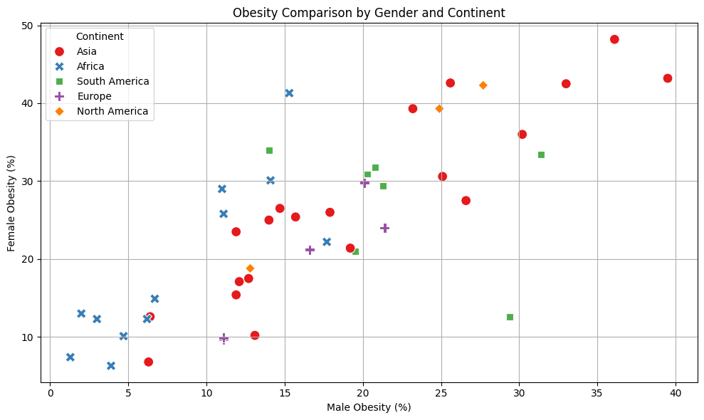

```python
plt.figure(figsize=(10, 6))
sns.scatterplot(
    data=obesity_world_finaldata,
    x="Males_Obesity",
    y="Females_Obesity",
    hue="Continent",
    style="Continent",
    palette="Set1",
    s=100
)
plt.title("Obesity Comparison by Gender and Continent")
plt.xlabel("Male Obesity (%)")
plt.ylabel("Female Obesity (%)")
plt.grid(True)
plt.tight_layout()
plt.show()
```

[figure not shown]

```python
# Cluster Comparison of Health, Economic, and Obesity Indicators

# Selected features
cluster_features = ["Health_Expenditure", "GDP_Per_Capita", "Urban_Pop_Percent", "Literacy_Rate", "Physicians_per_1000"]
X = obesity_world_finaldata[cluster_features]

# Standardize the features
scaler = StandardScaler()
X_scaled = scaler.fit_transform(X)

# Apply KMeans clustering
kmeans = KMeans(n_clusters=3, random_state=42)
obesity_world_finaldata["Cluster"] = kmeans.fit_predict(X_scaled)

# Summarize cluster profiles
cluster_summary = obesity_world_finaldata.groupby("Cluster")[cluster_features + ["Continent"]].agg({
    "Health_Expenditure": "mean",
    "GDP_Per_Capita": "mean",
    "Urban_Pop_Percent": "mean",
    "Literacy_Rate": "mean",
    "Physicians_per_1000": "mean",
    "Continent": lambda x: x.value_counts().idxmax()
}).round(2)

# Rename clusters for interpretability
cluster_labels = {
    0: "Low GDP & Health Spend",
    1: "High Obesity & Middle GDP",
    2: "High GDP & Health Spend"
}
cluster_summary.rename(index=cluster_labels, inplace=True)

# Data
plot_data = cluster_summary.reset_index().melt(
    id_vars='Cluster',
    value_vars=cluster_features,
    var_name='Variable',
    value_name='Average Value'
)

# Plot
plt.figure(figsize=(10, 6))
ax = sns.barplot(
    data=plot_data,
    x="Variable",
    y="Average Value",
    hue="Cluster",
    palette="Set1"
)

# Annotate values on bars
for container in ax.containers:
    ax.bar_label(container, fmt='%.0f', label_type='edge', fontsize=9)

# Result
plt.title("Cluster Comparison of Health, Economic, and Obesity Indicators", fontsize=14)
plt.xlabel("Indicator", fontsize=12)
plt.ylabel("Average Value", fontsize=12)
plt.xticks(rotation=0, fontsize=11)
plt.yticks(fontsize=11)
plt.legend(title="Cluster", title_fontsize=10)
plt.grid(axis='y', linestyle='--', alpha=0.7)
plt.tight_layout()
plt.show()
```

We can set our binary class label on whether or not a country is obese by first creating a histogram of the obesity rates.

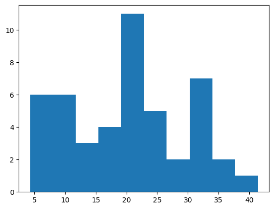

```python
plt.hist(obesity_world_finaldata["Adults_Obesity"])
```

```python
obesity_world_finaldata["Adults_Obesity"].quantile(.75)
```

```
np.float64(26.6)
```

```python
# Create binary class label from Adults_Obesity: "yes" if obesity rate is >= 30%, else "no"
obesity_world_finaldata["Obese_Class"] = obesity_world_finaldata["Adults_Obesity"].apply(
    lambda x: "yes" if x >= 26 else "no"
)
```

```python
accuracies={}
```

# 4 Decision Trees (Simple Classification)#

```python
#We initialize recall (or true positive) and a precision dictionary to capture metrics
recalls={}
precisions={}
```

Now we move onto using descision trees to determine obesity rates.

```python
obesity_world_finaldata.head()
```

|  | Country | Year | Males_Obesity | Females_Obesity | Adults_Obesity | Health_Expenditure | GDP_Per_Capita | Literacy_Rate | Physicians_per_1000 | Urban_Pop_Percent | Women_Empowerment | Continent | Cluster | Obese_Class |
| --- | --- | --- | --- | --- | --- | --- | --- | --- | --- | --- | --- | --- | --- | --- |
| 0 | Afghanistan | 2018 | 11.9 | 23.5 | 17.0 | 59.919605 | 565.569730 | 33.753841 | 0.2910 | 24.803 | 0.503 | Asia | 2 | no |
| 1 | Algeria | 2016 | 14.1 | 30.1 | 21.8 | 271.537781 | 4577.210292 | 81.407837 | 1.7320 | 72.629 | 0.791 | Africa | 1 | no |
| 2 | Argentina | 2018 | 31.4 | 33.4 | 32.4 | 668.793091 | 7141.475077 | 97.000000 | 3.2481 | 89.329 | 0.856 | South America | 1 | yes |
| 3 | Armenia | 2016 | 14.0 | 25.0 | 19.5 | 409.801453 | 3869.053739 | 100.000000 | 2.9720 | 63.103 | 0.749 | Asia | 1 | no |
| 4 | Azerbaijan | 2017 | 14.7 | 26.5 | 20.6 | 199.257462 | 4805.753718 | 100.000000 | 3.1110 | 56.031 | 0.643 | Asia | 1 | no |

```python
obesity_world_finaldata.info()
```

```
<class 'pandas.core.frame.DataFrame'>
RangeIndex: 47 entries, 0 to 46
Data columns (total 14 columns):
 #   Column               Non-Null Count  Dtype
---  ------               --------------  -----
 0   Country              47 non-null     object
 1   Year                 47 non-null     int64
 2   Males_Obesity        47 non-null     float64
 3   Females_Obesity      47 non-null     float64
 4   Adults_Obesity       47 non-null     float64
 5   Health_Expenditure   47 non-null     float64
 6   GDP_Per_Capita       47 non-null     float64
 7   Literacy_Rate        47 non-null     float64
 8   Physicians_per_1000  47 non-null     float64
 9   Urban_Pop_Percent    47 non-null     float64
 10  Women_Empowerment    47 non-null     float64
 11  Continent            47 non-null     object
 12  Cluster              47 non-null     int32
 13  Obese_Class          47 non-null     object
dtypes: float64(9), int32(1), int64(1), object(3)
memory usage: 5.1+ KB
```

```python
df=obesity_world_finaldata.copy()

#Convert Obese_Class to categorical
df['Obese_Class'] = df['Obese_Class'].astype('category')
lb = LabelBinarizer()
df['Obese_Class'] = lb.fit_transform(df['Obese_Class'])

encoder = OneHotEncoder(handle_unknown='ignore')
encoded_col = pd.DataFrame(encoder.fit_transform(df[['Continent',"Cluster"]]).toarray())
encoded_col.columns = encoder.get_feature_names_out(['Continent', "Cluster"])
country_name=df["Country"]
df=df.drop(columns=["Country"])

df = df.reset_index(drop=True)


# concatenate numeric and encoded categorical columns
X = pd.concat([df.drop([ 'Males_Obesity', "Females_Obesity", "Adults_Obesity", "Continent", "Obese_Class", "Cluster"], axis=1), encoded_col], axis=1)
```

```python
# fit decision tree model
tree_simple_class = DecisionTreeClassifier(class_weight="balanced")
tree_simple_class.fit(X, df['Obese_Class'])
```

```
DecisionTreeClassifier(class_weight='balanced')
```

```python
tree_summary = export_text(tree_simple_class, feature_names=X.columns.tolist())
print(tree_summary)
```

```
|--- Urban_Pop_Percent <= 53.30
|   |--- class: 0
|--- Urban_Pop_Percent >  53.30
|   |--- Physicians_per_1000 <= 2.06
|   |   |--- Literacy_Rate <= 83.70
|   |   |   |--- class: 0
|   |   |--- Literacy_Rate >  83.70
|   |   |   |--- class: 1
|   |--- Physicians_per_1000 >  2.06
|   |   |--- Urban_Pop_Percent <= 85.19
|   |   |   |--- Physicians_per_1000 <= 5.02
|   |   |   |   |--- Cluster_0 <= 0.50
|   |   |   |   |   |--- class: 0
|   |   |   |   |--- Cluster_0 >  0.50
|   |   |   |   |   |--- class: 0
|   |   |   |--- Physicians_per_1000 >  5.02
|   |   |   |   |--- Continent_North America <= 0.50
|   |   |   |   |   |--- class: 1
|   |   |   |   |--- Continent_North America >  0.50
|   |   |   |   |   |--- class: 0
|   |   |--- Urban_Pop_Percent >  85.19
|   |   |   |--- Year <= 2018.50
|   |   |   |   |--- Cluster_1 <= 0.50
|   |   |   |   |   |--- class: 1
|   |   |   |   |--- Cluster_1 >  0.50
|   |   |   |   |   |--- class: 1
|   |   |   |--- Year >  2018.50
|   |   |   |   |--- class: 0
```

```python
importances = pd.DataFrame({'feature_name': X.columns, 'importance': tree_simple_class.feature_importances_})
importances = importances.sort_values('importance', ascending=False).reset_index(drop=True)
print(importances)
```

```
               feature_name    importance
0         Urban_Pop_Percent  5.153474e-01
1       Physicians_per_1000  2.313302e-01
2             Literacy_Rate  1.107692e-01
3                      Year  1.000000e-01
4   Continent_North America  4.255319e-02
5                 Cluster_0  1.480297e-16
6                 Cluster_1  9.516197e-17
7         Women_Empowerment  0.000000e+00
8            GDP_Per_Capita  0.000000e+00
9        Health_Expenditure  0.000000e+00
10         Continent_Africa  0.000000e+00
11         Continent_Europe  0.000000e+00
12           Continent_Asia  0.000000e+00
13  Continent_South America  0.000000e+00
14                Cluster_2  0.000000e+00
```

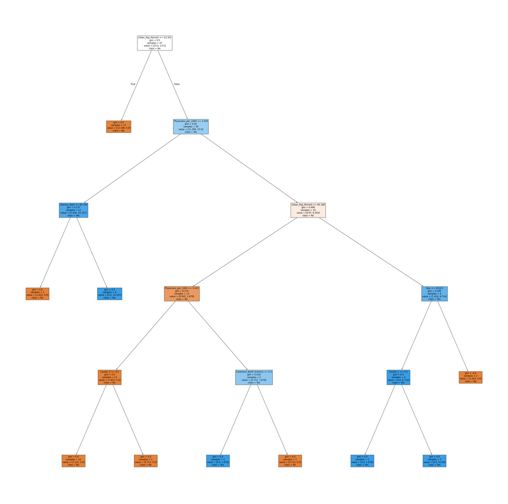

```python
plt.figure(figsize=(50,50))
plot_tree(tree_simple_class
          , filled=True
          , feature_names=X.columns
          , class_names=['No', 'Yes']
          , label='all'
          , fontsize=12)
plt.show()
```

The above model is trained on *all* the data. We can't evaluate it's effectiveness, but we can compare its structure to on that only takes a subsection of the data.

```python
# Split the Data between test and train
X_train, X_test, y_train, y_test = train_test_split(X, df['Obese_Class']
                                                    , train_size = 0.6, test_size = 0.4
                                                    , random_state = 1, stratify=df['Obese_Class'])
# fit decision tree model
tree_simple_class = DecisionTreeClassifier(class_weight="balanced")
tree_simple_class.fit(X_train, y_train)

# predict on test data
tree_pred = tree_simple_class.predict(X_test)

# create confusion matrix
confusion_matrix = pd.crosstab(index=tree_pred, columns=y_test, rownames=[''])
print(confusion_matrix)
```

```
Obese_Class  0  1

0            7  3
1            6  3
```

```python
# Calculate the accuracy of the decision tree on the test data
accuracy = tree_simple_class.score(X_test, y_test)
print("Accuracy: {:.2f}%".format(accuracy*100))

accuracies["Simple"]=accuracy
recalls["Simple"]=metrics.recall_score(y_test, tree_pred)
precisions["Simple"]=metrics.precision_score(y_test,tree_pred)
```

```
Accuracy: 52.63%
```

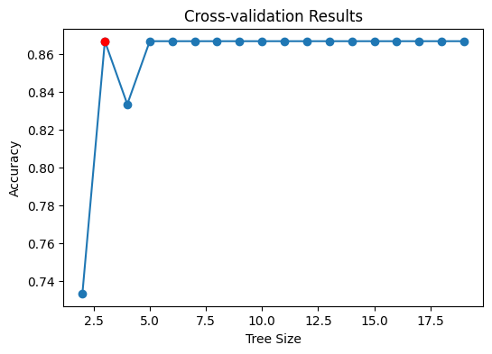

```python
# fit decision tree model
tree_simple_tuning = DecisionTreeClassifier(random_state=2, class_weight="balanced")
tree_simple_tuning.fit(X_train, y_train)

# cross-validation to determine optimal tree size
params = {'max_leaf_nodes': range(2, 20)}
cv_simple_tuning = GridSearchCV(tree_simple_tuning, params, cv=10)
cv_simple_tuning.fit(X_train, y_train)
cv_results = cv_simple_tuning.cv_results_

# find the best score for max leaf nodes
best_size = cv_simple_tuning.best_params_['max_leaf_nodes']
best_score = cv_simple_tuning.best_score_

# plot results of cross-validation
plt.figure(figsize=(6, 4))
plt.plot(cv_results["param_max_leaf_nodes"], cv_results["mean_test_score"], 'o-')
plt.plot(best_size, best_score, 'ro-')
plt.xlabel('Tree Size')
plt.ylabel('Accuracy')
plt.title('Cross-validation Results');
```

There is something unusualy about this cross validation. It can either be very unstable or not change at all. One can suspect this has to do with the instability of the training set.

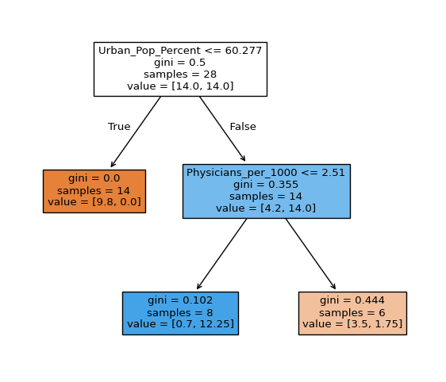

```python
# prune tree using optimal size
prune_simple = DecisionTreeClassifier(max_leaf_nodes=best_size, random_state=2, class_weight="balanced")
prune_simple.fit(X_train, y_train)

# plot pruned tree
plt.figure(figsize=(7,6))
plt.title('Pruned Tree')
plot_tree(prune_simple, feature_names=X_train.columns, filled=True);
```

```python
# obtain predicted labels for test set
y_pred = prune_simple.predict(X_test)

# create confusion matrix
confusion_matrix = pd.crosstab(index=y_pred, columns=y_test, rownames=[''])
print(confusion_matrix)
```

```
Obese_Class  0  1

0            8  3
1            5  3
```

```python
# Calculate the accuracy of the decision tree on the test data
accuracy = prune_simple.score(X_test, y_test)
print("Accuracy: {:.2f}%".format(accuracy*100))
accuracies["Simple_Pruned"]=accuracy
recalls["Simple_Pruned"]=metrics.recall_score(y_test, y_pred)
recalls["Simple_Pruned"]=metrics.precision_score(y_test, y_pred)
```

```
Accuracy: 57.89%
```

```python
importances = pd.DataFrame({'feature_name': X_train.columns, 'importance': prune_simple.feature_importances_})
importances = importances.sort_values('importance', ascending=False).reset_index(drop=True)
print(importances)
```

```
               feature_name  importance
0         Urban_Pop_Percent    0.728893
1       Physicians_per_1000    0.271107
2                      Year    0.000000
3            GDP_Per_Capita    0.000000
4        Health_Expenditure    0.000000
5             Literacy_Rate    0.000000
6         Women_Empowerment    0.000000
7          Continent_Africa    0.000000
8            Continent_Asia    0.000000
9          Continent_Europe    0.000000
10  Continent_North America    0.000000
11  Continent_South America    0.000000
12                Cluster_0    0.000000
13                Cluster_1    0.000000
14                Cluster_2    0.000000
```

Compare it to analyses without the cluster. The cluster was previously comprised of many features except for those relating to obesity.

```python
# concatenate numeric and encoded categorical columns
X_nocluster = X.drop(columns=["Cluster_0", "Cluster_1", "Cluster_2"])
# fit decision tree model
tree_no_cluster = DecisionTreeClassifier(class_weight="balanced")
tree_no_cluster.fit(X_nocluster, df['Obese_Class'])
```

```
DecisionTreeClassifier(class_weight='balanced')
```

```python
tree_summary = export_text(tree_no_cluster, feature_names=X_nocluster.columns.tolist())
print(tree_summary)
```

```
|--- Urban_Pop_Percent <= 53.30
|   |--- class: 0
|--- Urban_Pop_Percent >  53.30
|   |--- Physicians_per_1000 <= 2.06
|   |   |--- Literacy_Rate <= 83.70
|   |   |   |--- class: 0
|   |   |--- Literacy_Rate >  83.70
|   |   |   |--- class: 1
|   |--- Physicians_per_1000 >  2.06
|   |   |--- Urban_Pop_Percent <= 85.19
|   |   |   |--- Physicians_per_1000 <= 5.02
|   |   |   |   |--- Continent_South America <= 0.50
|   |   |   |   |   |--- class: 0
|   |   |   |   |--- Continent_South America >  0.50
|   |   |   |   |   |--- class: 0
|   |   |   |--- Physicians_per_1000 >  5.02
|   |   |   |   |--- Physicians_per_1000 <= 7.10
|   |   |   |   |   |--- class: 1
|   |   |   |   |--- Physicians_per_1000 >  7.10
|   |   |   |   |   |--- class: 0
|   |   |--- Urban_Pop_Percent >  85.19
|   |   |   |--- Year <= 2018.50
|   |   |   |   |--- Physicians_per_1000 <= 2.38
|   |   |   |   |   |--- class: 1
|   |   |   |   |--- Physicians_per_1000 >  2.38
|   |   |   |   |   |--- class: 1
|   |   |   |--- Year >  2018.50
|   |   |   |   |--- class: 0
```

```python
importances = pd.DataFrame({'feature_name': X_nocluster.columns, 'importance': tree_no_cluster.feature_importances_})
importances = importances.sort_values('importance', ascending=False).reset_index(drop=True)
print(importances)
```

```
               feature_name    importance
0         Urban_Pop_Percent  5.153474e-01
1       Physicians_per_1000  2.738833e-01
2             Literacy_Rate  1.107692e-01
3                      Year  1.000000e-01
4   Continent_South America  1.480297e-16
5        Health_Expenditure  0.000000e+00
6            GDP_Per_Capita  0.000000e+00
7         Women_Empowerment  0.000000e+00
8          Continent_Africa  0.000000e+00
9            Continent_Asia  0.000000e+00
10         Continent_Europe  0.000000e+00
11  Continent_North America  0.000000e+00
```

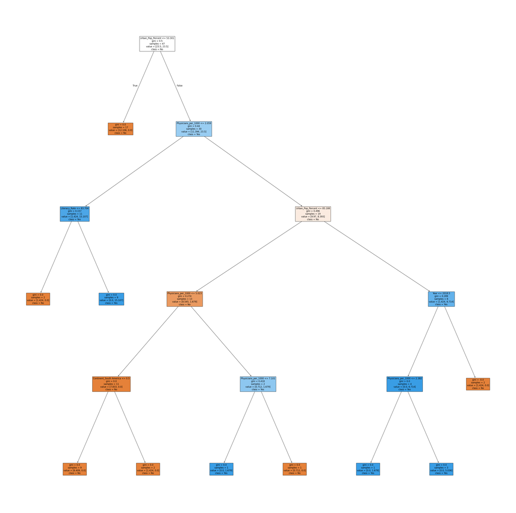

```python
plt.figure(figsize=(50,50))
plot_tree(tree_no_cluster
          , filled=True
          , feature_names=X.columns
          , class_names=['No', 'Yes']
          , label='all'
          , fontsize=12)
plt.show()
```

```python
# Split the Data between test and train
X_train, X_test, y_train, y_test = train_test_split(X_nocluster, df['Obese_Class']
                                                    , train_size = 0.6, test_size = 0.4
                                                    , random_state = 1, stratify=df['Obese_Class'])
# fit decision tree model
tree_no_cluster = DecisionTreeClassifier(class_weight="balanced")
tree_no_cluster.fit(X_train, y_train)

# predict on test data
tree_pred = tree_no_cluster.predict(X_test)

# create confusion matrix
confusion_matrix = pd.crosstab(index=tree_pred, columns=y_test, rownames=[''])
print(confusion_matrix)
```

```
Obese_Class  0  1

0            8  3
1            5  3
```

```python
# Calculate the accuracy of the decision tree on the test data
accuracy = tree_no_cluster.score(X_test, y_test)
print("Accuracy: {:.2f}%".format(accuracy*100))
accuracies["Simple_Clusterless"]=accuracy
recalls["Simple_Clusterless"]=metrics.recall_score(y_test, y_pred)
precisions["Simple_Clusterless"]=metrics.precision_score(y_test, y_pred)
```

```
Accuracy: 57.89%
```

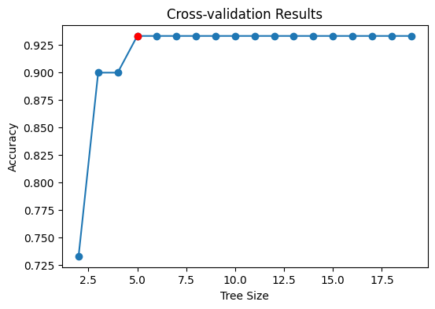

```python
# fit decision tree model
tree_clusterless = DecisionTreeClassifier(random_state=7, class_weight="balanced")
tree_clusterless.fit(X_train, y_train)

# cross-validation to determine optimal tree size
params = {'max_leaf_nodes': range(2, 20)}
cv_clusterless = GridSearchCV(tree_clusterless, params, cv=10)
cv_clusterless.fit(X_train, y_train)
cv_results = cv_clusterless.cv_results_

# find the best score for max leaf nodes
best_size = cv_clusterless.best_params_['max_leaf_nodes']
best_score = cv_clusterless.best_score_

# plot results of cross-validation
plt.figure(figsize=(6, 4))
plt.plot(cv_results["param_max_leaf_nodes"], cv_results["mean_test_score"], 'o-')
plt.plot(best_size, best_score, 'ro-')
plt.xlabel('Tree Size')
plt.ylabel('Accuracy')
plt.title('Cross-validation Results');
```

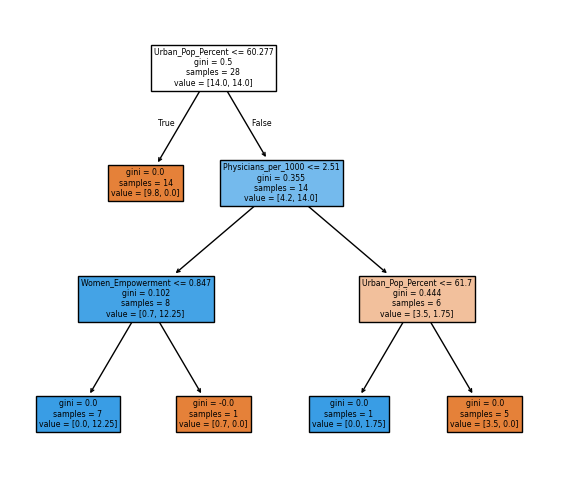

```python
# prune tree using optimal size
prune_clusterless = DecisionTreeClassifier(max_leaf_nodes=best_size, random_state=7, class_weight="balanced")
prune_clusterless.fit(X_train, y_train)

# plot pruned tree
plt.figure(figsize=(7,6))
plt.title('Pruned Tree')
plot_tree(prune_clusterless, feature_names=X_train.columns, filled=True);
```

```python
# obtain predicted labels for test set
y_pred = prune_clusterless.predict(X_test)

# create confusion matrix
confusion_matrix = pd.crosstab(index=y_pred, columns=y_test, rownames=[''])
print(confusion_matrix)
```

```
Obese_Class  0  1

0            8  3
1            5  3
```

```python
# Calculate the accuracy of the decision tree on the test data
accuracy = prune_clusterless.score(X_test, y_test)
print("Accuracy: {:.2f}%".format(accuracy*100))
accuracies["Prune_Clusterless"]=accuracy
recalls["Prune_Clusterless"]=metrics.recall_score(y_test, y_pred)
precisions["Prune_Clusterless"]=metrics.precision_score(y_test, y_pred)
```

```
Accuracy: 57.89%
```

```python
importances = pd.DataFrame({'feature_name': X_train.columns, 'importance': prune_clusterless.feature_importances_})
importances = importances.sort_values('importance', ascending=False).reset_index(drop=True)
print(importances)
```

```
               feature_name  importance
0         Urban_Pop_Percent    0.705128
1       Physicians_per_1000    0.200277
2         Women_Empowerment    0.094595
3                      Year    0.000000
4             Literacy_Rate    0.000000
5            GDP_Per_Capita    0.000000
6        Health_Expenditure    0.000000
7          Continent_Africa    0.000000
8            Continent_Asia    0.000000
9          Continent_Europe    0.000000
10  Continent_North America    0.000000
11  Continent_South America    0.000000
```

Let's see if we can optimize our obesity value to the median, and naturally balance our classes. Class_weight="balanced" usually handles this, but let's see if we can artifically set it.

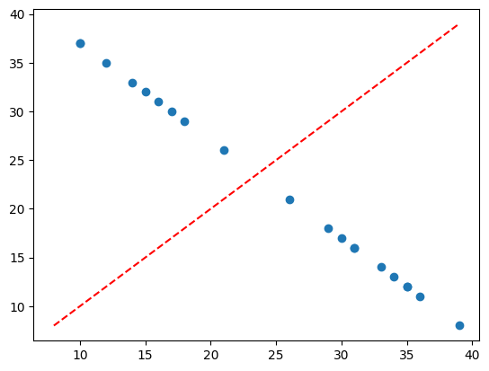

```python
balance_yes=[]
balance_no=[]
for k in range(10,30):

  obesity_world_finaldata["Obese_Class"] = obesity_world_finaldata["Adults_Obesity"].apply(
    lambda x: "yes" if x >= k else "no"
  )
  balance_yes.append(obesity_world_finaldata['Obese_Class'].value_counts().get('yes', 0))
  balance_no.append(obesity_world_finaldata['Obese_Class'].value_counts().get('no', 0))
plt.scatter(balance_yes, balance_no)
x=balance_yes
y=balance_no
min_val = min(min(x), min(y))
max_val = max(max(x), max(y))
plt.plot([min_val, max_val], [min_val, max_val], color='red', linestyle='--', label='x = y')
```

```python
X["Obese_Class"] = df["Adults_Obesity"].apply(
    lambda x: 1 if x >= 18 else 0
  )
```

```python
# Split the Data between test and train
X_train, X_test, y_train, y_test = train_test_split(X.drop(columns="Obese_Class"), X['Obese_Class']
                                                    , train_size = 0.6, test_size = 0.4
                                                    , random_state = 1, stratify=X['Obese_Class'])

# fit decision tree model
tree_balance = DecisionTreeClassifier()
tree_balance.fit(X_train, y_train)
```

```
DecisionTreeClassifier()
```

```python
tree_summary = export_text(tree_balance, feature_names=X.drop(columns="Obese_Class").columns.tolist())
print(tree_summary)
```

```
|--- Urban_Pop_Percent <= 50.12
|   |--- class: 0
|--- Urban_Pop_Percent >  50.12
|   |--- Physicians_per_1000 <= 2.38
|   |   |--- class: 1
|   |--- Physicians_per_1000 >  2.38
|   |   |--- Literacy_Rate <= 99.50
|   |   |   |--- Urban_Pop_Percent <= 80.70
|   |   |   |   |--- class: 0
|   |   |   |--- Urban_Pop_Percent >  80.70
|   |   |   |   |--- Health_Expenditure <= 3147.07
|   |   |   |   |   |--- class: 1
|   |   |   |   |--- Health_Expenditure >  3147.07
|   |   |   |   |   |--- class: 0
|   |   |--- Literacy_Rate >  99.50
|   |   |   |--- class: 1
```

```python
importances = pd.DataFrame({'feature_name': X.drop(columns="Obese_Class").columns, 'importance': tree_balance.feature_importances_})
importances = importances.sort_values('importance', ascending=False).reset_index(drop=True)
print(importances)
```

```
               feature_name  importance
0         Urban_Pop_Percent    0.566304
1       Physicians_per_1000    0.219807
2        Health_Expenditure    0.116667
3             Literacy_Rate    0.097222
4                      Year    0.000000
5            GDP_Per_Capita    0.000000
6         Women_Empowerment    0.000000
7          Continent_Africa    0.000000
8            Continent_Asia    0.000000
9          Continent_Europe    0.000000
10  Continent_North America    0.000000
11  Continent_South America    0.000000
12                Cluster_0    0.000000
13                Cluster_1    0.000000
14                Cluster_2    0.000000
```

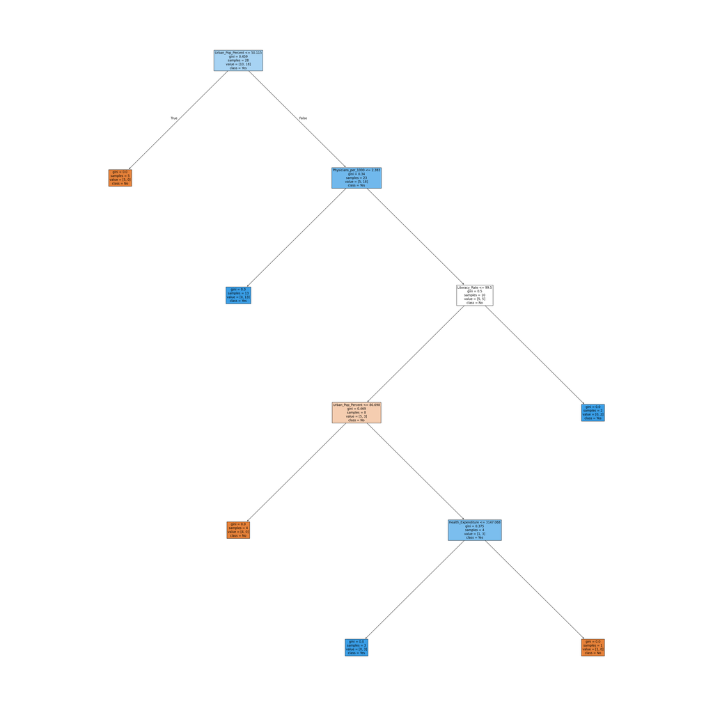

```python
plt.figure(figsize=(50,50))
plot_tree(tree_balance
          , filled=True
          , feature_names=X.columns
          , class_names=['No', 'Yes']
          , label='all'
          , fontsize=12)
plt.show()
```

```python
# Calculate the accuracy of the decision tree on the test data
accuracy = tree_balance.score(X_test, y_test)
print("Accuracy: {:.2f}%".format(accuracy*100))
y_pred=tree_balance.predict(X_test)
accuracies["Artificial_Balance"]=accuracy
recalls["Artificial_Balance"]=metrics.recall_score(y_test, y_pred)
precisions["Artificial_Balance"]=metrics.precision_score(y_test, y_pred)
```

```
Accuracy: 84.21%
```

```python
df=obesity_world_finaldata.copy()

#Convert Obese_Class to categorical
df['Obese_Class'] = df['Obese_Class'].astype('category')
lb = LabelBinarizer()
df['Obese_Class'] = lb.fit_transform(df['Obese_Class'])

encoder = OneHotEncoder(handle_unknown='ignore')
encoded_col = pd.DataFrame(encoder.fit_transform(df[['Continent',"Cluster"]]).toarray())
encoded_col.columns = encoder.get_feature_names_out(['Continent', "Cluster"])
country_name=df["Country"]
df=df.drop(columns=["Country"])

df = df.reset_index(drop=True)


# concatenate numeric and encoded categorical columns
X = pd.concat([df.drop([ 'Males_Obesity', "Females_Obesity", "Adults_Obesity", "Continent", "Obese_Class", "Cluster"], axis=1), encoded_col], axis=1)
```

# 5 Bagging Classification#

Now we try some more advanced trees

```python
X_train, X_test, y_train, y_test =  train_test_split(X,
                                                 df['Obese_Class'],
                                                 train_size = 0.6, test_size = 0.4
                                                 ,random_state = 1)
```

```python
bagging = RandomForestClassifier(max_features=X_train.shape[1],random_state = 1, class_weight="balanced")
bagging.fit(X_train,y_train)

print("Number of trees:", bagging.n_estimators)
print("Number of features tried at each split:",bagging.max_features)
print("Training score: {:.2f}%".format(bagging.score(X_train,y_train)*100))

y_pred_bag=bagging.predict(X_test)
```

```
Number of trees: 100
Number of features tried at each split: 15
Training score: 100.00%
```

```python
confusion_matrix = pd.crosstab(index=y_pred_bag, columns=y_test, rownames=[''])
print(confusion_matrix)
```

```
Obese_Class   0  1

0            15  3
1             1  0
```

```python
error=np.diag(confusion_matrix).sum()/confusion_matrix.values.sum()
print(error)
```

```
0.7894736842105263
```

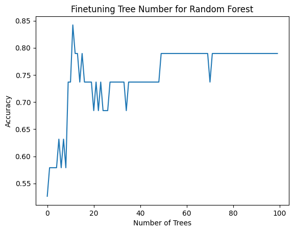

```python
errors=[]
for i in range(100):
  bagging = RandomForestClassifier(max_features=X_train.shape[1]
                                       ,random_state = 1
                                       ,n_estimators=i+1, class_weight="balanced")

  bagging.fit(X_train,y_train)

# Predict values
  y_pred_bag = bagging.predict(X_test)

# find the MSE
  confusion_matrix = pd.crosstab(index=y_pred_bag, columns=y_test, rownames=[''])
  error=np.diag(confusion_matrix).sum()/confusion_matrix.values.sum()
  errors.append(error)

plt.plot(errors)
plt.title("Finetuning Tree Number for Random Forest")
plt.ylabel("Accuracy")
plt.xlabel("Number of Trees")
```

```python
max(errors)
```

```
np.float64(0.8421052631578947)
```

```python
errors.index(max(errors))
```

```
11
```

```python
accuracies["Bagging"]=max(errors)
bagging = RandomForestClassifier(max_features=X_train.shape[1]
                                       ,random_state = 1
                                       ,n_estimators=12, class_weight="balanced")
bagging.fit(X_train, y_train)
y_pred=bagging.predict(X_test)
recalls["Bagging"]=metrics.recall_score(y_test, y_pred)
precisions["Bagging"]=metrics.precision_score(y_test,y_pred)
```

```python
importances = pd.DataFrame({'feature_name': X_train.columns, 'importance': bagging.feature_importances_})
importances = importances.sort_values('importance', ascending=False).reset_index(drop=True)
print(importances)
```

```
               feature_name  importance
0         Women_Empowerment    0.170602
1            GDP_Per_Capita    0.157152
2         Urban_Pop_Percent    0.142056
3                 Cluster_1    0.131528
4       Physicians_per_1000    0.130919
5        Health_Expenditure    0.091970
6            Continent_Asia    0.060800
7             Literacy_Rate    0.042532
8   Continent_South America    0.041904
9                      Year    0.030537
10         Continent_Africa    0.000000
11  Continent_North America    0.000000
12         Continent_Europe    0.000000
13                Cluster_0    0.000000
14                Cluster_2    0.000000
```

# 6 Random Forest Classification#

```python
# fit Random Forests model
rf = RandomForestClassifier(max_features=6
                                       ,random_state = 1, class_weight="balanced")

rf.fit(X_train,y_train)

# Predict values
y_pred_rf = rf.predict(X_test)
```

```python
confusion_matrix = pd.crosstab(index=y_pred_rf, columns=y_test, rownames=[''])
print(confusion_matrix)
print(np.diag(confusion_matrix).sum()/confusion_matrix.values.sum())
```

```
Obese_Class   0  1

0            15  3
1             1  0
0.7894736842105263
```

```python
# create a dataframe of feature importances and their corresponding column names
importances_rf = pd.DataFrame({'Feature': X_train.columns, 'Importance': rf.feature_importances_})
importances_rf = importances_rf.sort_values('Importance', ascending=False).reset_index(drop=True)

# display the table
print(importances_rf)
```

```
                    Feature  Importance
0       Physicians_per_1000    0.127283
1            GDP_Per_Capita    0.117897
2         Women_Empowerment    0.115902
3                 Cluster_1    0.107874
4         Urban_Pop_Percent    0.105824
5             Literacy_Rate    0.094915
6        Health_Expenditure    0.087199
7            Continent_Asia    0.080971
8                      Year    0.053564
9   Continent_South America    0.039711
10  Continent_North America    0.032486
11                Cluster_2    0.017024
12         Continent_Europe    0.009580
13         Continent_Africa    0.004956
14                Cluster_0    0.004813
```

```python
errors=[]
for i in range(X_train.shape[1]):
  rf = RandomForestClassifier(max_features=i+1
                                       ,random_state = 1, class_weight="balanced")

  rf.fit(X_train,y_train)

# Predict values
  y_pred_rf = rf.predict(X_test)


  confusion_matrix = pd.crosstab(index=y_pred_rf, columns=y_test, rownames=[''])
  errors.append(np.diag(confusion_matrix).sum()/confusion_matrix.values.sum())
```

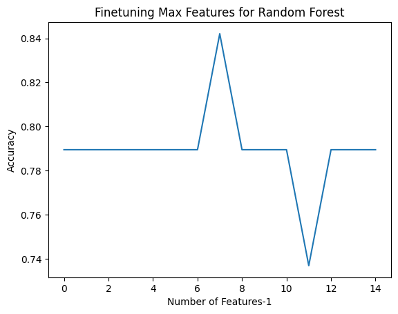

```python
plt.plot(errors)
plt.xlabel("Number of Features-1")
plt.ylabel("Accuracy")
plt.title("Finetuning Max Features for Random Forest")
```

```python
# fit Random Forests model
rf = RandomForestClassifier(max_features=np.argmax(errors)-1
                                       ,random_state = 1, class_weight="balanced")

rf.fit(X_train,y_train)

# Predict values
y_pred_rf = rf.predict(X_test)
confusion_matrix = pd.crosstab(index=y_pred_rf, columns=y_test, rownames=[''])
print(confusion_matrix)
print(np.diag(confusion_matrix).sum()/confusion_matrix.values.sum())
accuracies["RF_Tuned"]=np.diag(confusion_matrix).sum()/confusion_matrix.values.sum()
recalls["RF_Tuned"]=metrics.recall_score(y_test, y_pred_rf)
precisions["RF_Tuned"]=metrics.precision_score(y_test, y_pred_rf)
```

```
Obese_Class   0  1

0            15  3
1             1  0
0.7894736842105263
```

```python
# create a dataframe of feature importances and their corresponding column names
importances_rf = pd.DataFrame({'Feature': X_train.columns, 'Importance': rf.feature_importances_})
importances_rf = importances_rf.sort_values('Importance', ascending=False).reset_index(drop=True)

# display the table
print(importances_rf)
```

```
                    Feature  Importance
0       Physicians_per_1000    0.127283
1            GDP_Per_Capita    0.117897
2         Women_Empowerment    0.115902
3                 Cluster_1    0.107874
4         Urban_Pop_Percent    0.105824
5             Literacy_Rate    0.094915
6        Health_Expenditure    0.087199
7            Continent_Asia    0.080971
8                      Year    0.053564
9   Continent_South America    0.039711
10  Continent_North America    0.032486
11                Cluster_2    0.017024
12         Continent_Europe    0.009580
13         Continent_Africa    0.004956
14                Cluster_0    0.004813
```